# When Classes Collapse: Diagnosing Bayesian GMM Failures

Doria Xiao

# Overview

This demo accompanies the paper *Bayesian Identification and Estimation of Growth Mixture Models* (Psychometrika, 2025). It illustrates how Bayesian Growth Mixture Models (GMMs) can exhibit **degenerate nonidentifiability**, leading to misleading inferences—even when conventional diagnostics indicate convergence.

We focus on two distinct failure modes associated with **Type I nonidentifiability**:

- **Stuck-chain behavior**: MCMC chains become persistently stuck, often when one or more class probability parameters approach zero and are reinforced by incompatible draws of class-specific parameters.
- **Miniscule-class behavior**: A latent class receives consistently near-zero probability with minimal variance, resulting in a model that appears to sample properly but yields unstable or uninterpretable estimates.

These behaviors often arise when using diffuse or weakly regularizing priors and can remain hidden unless specifically diagnosed.

We demonstrate these issues using two prior configurations:

- **D2C5**: Dirichlet(α = 2) for class probabilities and Half-Cauchy(5) priors for standard deviations – resulting in stuck-chain behavior.
- **D2N500**: Dirichlet(α = 2) with Half-Normal(500) priors for standard deviations – resulting in miniscule-class behavior.

Each model is estimated using Stan with 20 chains (1,000 warmup and 1,000 sampling iterations). We apply a set of targeted diagnostics to detect hidden degeneracies:

- Corrected $\hat{R}$ from the `posterior` package
- Stuck-sequence detection based on rolling variance
- **Distinguishability Index (DI)** to evaluate class separation

Together, these diagnostics expose critical estimation failures that conventional tools often overlook.

# Step 1: Load Posterior Draws (D2C5 and D2N500)

```r
# Load draws after relabeling
NLSY_paths_rds_D2C5l <- list.files("~/.cmdstan/cmdstan-2.30.1/GMM_2/Identifiability/NLSY/MCMCResults_D2C5",
                                   full.names = TRUE, pattern="Stanl")
NLSY_contents_rds_D2C5l <- map(NLSY_paths_rds_D2C5l, readRDS)

file_paths_rds_D2C5l <- list.files("~/.cmdstan/cmdstan-2.30.1/GMM_2/Identifiability/NLSY/MCMCResults_D2C5",
                                  full.names = TRUE, pattern="repl")
file_contents_rds_D2C5l <- map(file_paths_rds_D2C5l, readRDS)
```

# Step 2: Load Diagnostic Functions

```r
# Custom diagnostics from Bayesian GMM paper
source("C:/Users/xingy/OneDrive/2023 Fall/BayesIdentify/Iden_diag_chain.R")
source("C:/Users/xingy/OneDrive/2023 Fall/BayesIdentify/diag_by_chain.R")
source("C:/Users/xingy/OneDrive/2023 Fall/BayesIdentify/twinlike_diag.R")
```

# Step 3: R̂ Diagnostic (D2C5: Stuck Chains)

Even when chains appear stable, they may be stuck in near-degenerate regions of the parameter space. Stan’s `monitor()` function may report $\hat{R} \approx 1$, masking these problems.

```r
kable(fit_permuted, caption = "Stan monitor() output: misleading R̂ values for stuck chains", digits = 3)
```

Stan monitor() output: misleading R̂ values for stuck chains

|  | Parameter | Q5 | Q50 | Q95 | mean | sd | Rhat | Bulk_ESS | Tail_ESS |
| --- | --- | --- | --- | --- | --- | --- | --- | --- | --- |
| lambda_1 | lambda_1 | 0.003 | 0.003 | 0.003 | 0.003 | 0 | 1 | 1000 | 1000 |
| sigma1_1 | sigma1_1 | 147.032 | 147.032 | 147.032 | 147.032 | 0 | 1 | 1000 | 1000 |
| sigma2_1 | sigma2_1 | 2919870.000 | 2919870.000 | 2919870.000 | 2919870.000 | 0 | 1 | 1000 | 1000 |
| lambda_2 | lambda_2 | 0.015 | 0.015 | 0.015 | 0.015 | 0 | 1 | 1000 | 1000 |
| sigma1_2 | sigma1_2 | 2.231 | 2.231 | 2.231 | 2.231 | 0 | 1 | 1000 | 1000 |
| sigma2_2 | sigma2_2 | 2.785 | 2.785 | 2.785 | 2.785 | 0 | 1 | 1000 | 1000 |
| lambda_3 | lambda_3 | 0.982 | 0.982 | 0.982 | 0.982 | 0 | 1 | 1000 | 1000 |
| sigma1_3 | sigma1_3 | 0.766 | 0.766 | 0.766 | 0.766 | 0 | 1 | 1000 | 1000 |
| sigma2_3 | sigma2_3 | 0.309 | 0.309 | 0.309 | 0.309 | 0 | 1 | 1000 | 1000 |
| mu_intercept_1 | mu_intercept_1 | -13.501 | -13.501 | -13.501 | -13.501 | 0 | 1 | 1000 | 1000 |
| mu_intercept_2 | mu_intercept_2 | 5.087 | 5.087 | 5.087 | 5.087 | 0 | 1 | 1000 | 1000 |
| mu_intercept_3 | mu_intercept_3 | 2.555 | 2.555 | 2.555 | 2.555 | 0 | 1 | 1000 | 1000 |
| mu_slope_1 | mu_slope_1 | 11.621 | 11.621 | 11.621 | 11.621 | 0 | 1 | 1000 | 1000 |
| mu_slope_2 | mu_slope_2 | 7.051 | 7.051 | 7.051 | 7.051 | 0 | 1 | 1000 | 1000 |
| mu_slope_3 | mu_slope_3 | 1.609 | 1.609 | 1.609 | 1.609 | 0 | 1 | 1000 | 1000 |
| sq_mu_slope_1 | sq_mu_slope_1 | -3.550 | -3.550 | -3.550 | -3.550 | 0 | 1 | 1000 | 1000 |
| sq_mu_slope_2 | sq_mu_slope_2 | -1.999 | -1.999 | -1.999 | -1.999 | 0 | 1 | 1000 | 1000 |
| sq_mu_slope_3 | sq_mu_slope_3 | -0.175 | -0.175 | -0.175 | -0.175 | 0 | 1 | 1000 | 1000 |
| Omega12_1 | Omega12_1 | -0.164 | -0.164 | -0.164 | -0.164 | 0 | 1 | 1000 | 1000 |
| Omega12_2 | Omega12_2 | -0.411 | -0.411 | -0.411 | -0.411 | 0 | 1 | 1000 | 1000 |
| Omega12_3 | Omega12_3 | 0.182 | 0.182 | 0.182 | 0.182 | 0 | 1 | 1000 | 1000 |

> ⚠️ **Note**: The `monitor()` function returns R̂ ≈ 1 does not guarantee convergence—particularly when chains are stuck in degenerate regions.

### Traceplots of Stuck Chains (Chains 1–4)

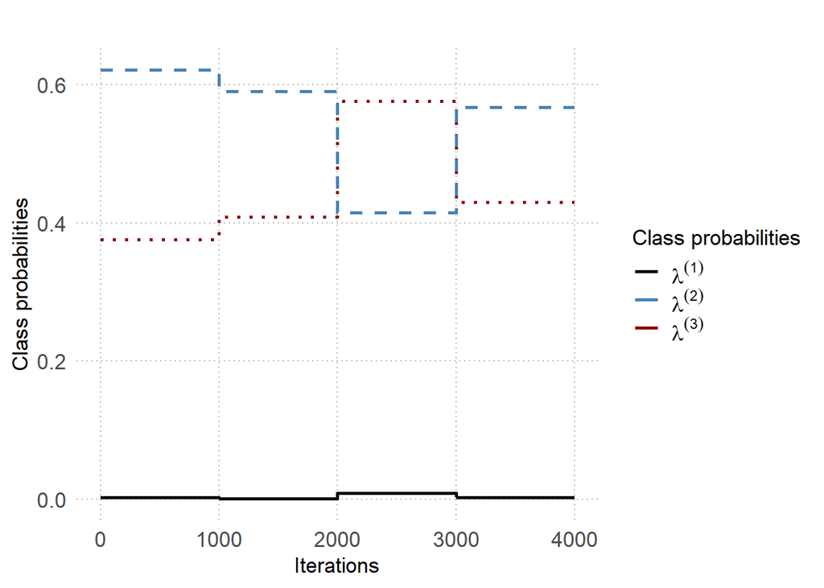

```r
traceplot(Data_reordered=traceData(priors, 1, 20000)$data,
          num_chains=c(1:4),
          iterations_per_chain=1000)$traceplot.by.chain
```

Visual inspection reveals frozen chains despite acceptable R̂.

### Corrected R̂ Diagnostic (posterior package)

```r
Data_reordered_nonPermu <- traceData_ESS(priors, 1, ESS_var = "lambda_1", ESS_chain=5)$data
resulting_arrays <- split_data_into_arrays(Data_reordered_nonPermu, chains_per_array = 4)
Rhat_diag_by_chains(resulting_arrays, small_threshold = 1.05)
```

```
## $Rhat_mean_by_array
## [1] Inf Inf Inf Inf Inf
```

The posterior package correctly flags $\hat{R} = \infty$ for chains that are frozen.

# Step 4: Stuck-Sequence Diagnostic

This diagnostic flags chains that stop updating over long windows — a classic sign of frozen sampling. In D2C5, this confirms the traceplot diagnosis and supports evidence of Type I degeneracy.

```r
stuck <- lapply(seq_along(priors),
                function(i)
                  stuck_by_chain(priors[[i]], i, total_iter = 20000,
                                 iter_per_chain = 1000, window_size = 10, stuck_length = 20))

# Number of completely stuck chains in Chain 1
stuck[[1]]$persistent_stuck_chain %>% length()
```

```
## [1] 20
```

```r
# How many chains show stuck behavior?
stuck[[1]]$num_chains_with_stuck
```

```
## [1] 20
```

### Step 5: Distinguishability Index (DI)

When two latent classes are nearly indistinguishable, the sampler cannot reliably separate them. This is often referred to as a **twin class** problem — a form of nonidentifiability that undermines interpretability.

We use the **Distinguishability Index (DI)** to detect this issue:

- **DI close to 0** → the two classes are nearly identical in posterior probabilities (i.e., *twinlike*).
- **DI close to 100** → one class dominates the other across iterations and individuals, often indicating **miniscule-class behavior**.

This makes DI a valuable diagnostic for both:

- **Type II degeneracy** (twin classes), and
- **Type I degeneracy** (near-zero class probabilities).

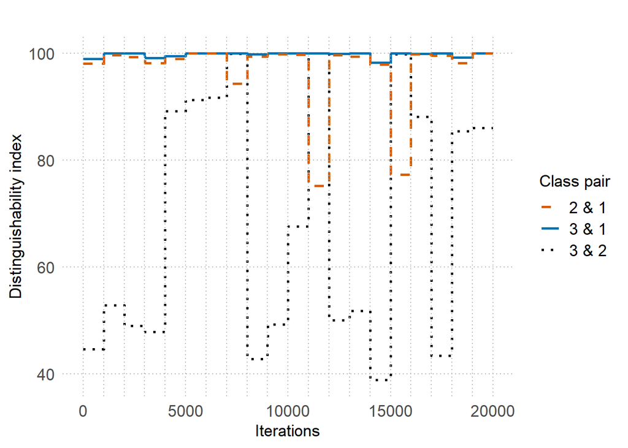

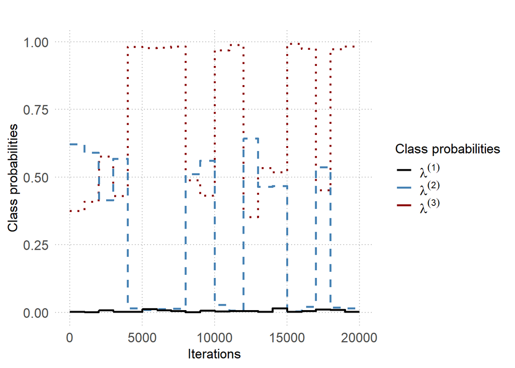

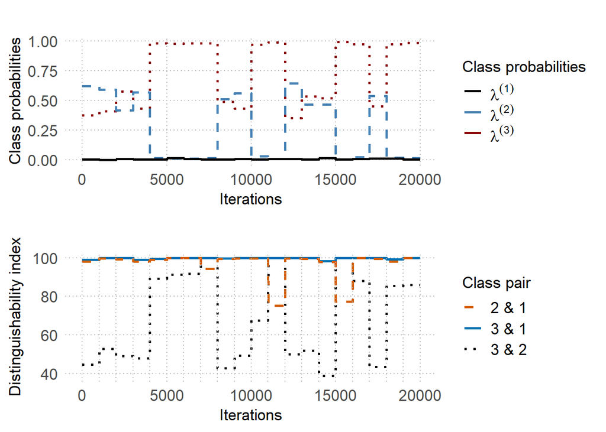

```
##
## $filtered_DI_values
## [1]  1  8  9 12 13 16 17
```

```r
log_l_D2C5l <- readRDS("~/.cmdstan/cmdstan-2.30.1/GMM_2/Identifiability/NLSY/MCMCResults_D2C5/log_l.rds")
DI_data <- read_rds("~/.cmdstan/cmdstan-2.30.1/GMM_2/Identifiability/NLSY/MCMCResults_D2C5/DI_data.rds")

# Run diagnostic

twinlike_classes(DI_data = DI_data,
                 selected_chains = c(1:20),
                 total_chains = 100,
                 iter_per_chain = 1000,
                 high_DI_value = 95,
                 persist_length = 3,
                 happen_times = 1)
```

# Step 6: Miniscule-Class Diagnostic (D2N500)

In the D2N500 configuration, we see repeated near-zero class probabilities for one latent class across chains. This is a second expression of Type I degeneracy: rather than getting stuck, the sampler avoids assigning individuals to the class at all.

```r
# Load draws after relabeling
NLSY_paths_rds_D2N500l <- list.files("~/.cmdstan/cmdstan-2.30.1/GMM_2/Identifiability/NLSY/MCMCResults_D2N500_sss",
                                   full.names = TRUE, pattern="Stanl")
NLSY_contents_rds_D2N500l <- map(NLSY_paths_rds_D2N500l, readRDS)

file_paths_rds_D2N500l <- list.files("~/.cmdstan/cmdstan-2.30.1/GMM_2/Identifiability/NLSY/MCMCResults_D2N500_sss",
                                  full.names = TRUE, pattern="repl")
file_contents_rds_D2N500l <- map(file_paths_rds_D2N500l, readRDS)
```

```r
priors <- file_contents_rds_D2N500l
DI_data <- read_rds("~/.cmdstan/cmdstan-2.30.1/GMM_2/Identifiability/NLSY/MCMCResults_D2N500_sss/DI_data.rds")

fluctuating_diag_by_chain(
  Data = traceData(priors, 1, 20000),
  window_size = 50,
  selected_chains = c(1:20),
  iter_per_chain = 1000,
  top_percentile_threshold = 0.95,
  DI_data = DI_data,
  total_chains = 20,
  high_DI_value = 95,
  persist_length = 3,
  happen_times = 1
)
```

```
## A persistent miniscule found
## Print the traceplot:
```

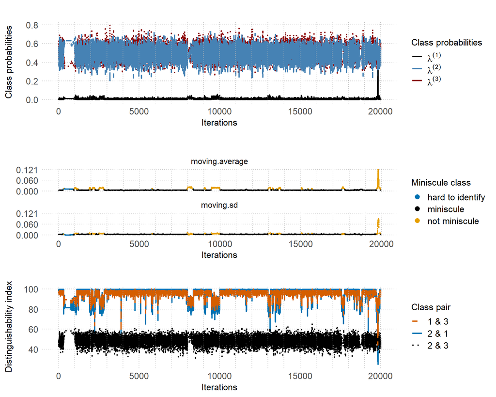

# Takeaways

- Do **not** rely solely on $\hat{R}$ from Stan’s `monitor()` or visual inspection of traceplots.
- Use diagnostics tailored for latent class models:
  - **Corrected $\hat{R}$** from the `posterior` package
  - **Stuck-sequence detection**
  - **Distinguishability Index (DI)**
- Avoid Half-Cauchy priors for standard deviations; they can promote degenerate draws.
- Prefer **weakly informative Half-Normal priors** and **moderate Dirichlet priors** (e.g., $\alpha = 6$ to $10$) to reduce the risk of Type I nonidentifiability.

Use these tools to go beyond standard convergence checks — and protect your inferences.

> 📄 View the full paper: https://doi.org/10.1017/psy.2025.11  
> 💻 View demo repo: https://github.com/DoriaXiao/BayesianIdentification